# Exploring the BRFSS data

## Setup

### Load packages

```r
library(ggplot2)
library(dplyr)
```

### Load data

Make sure your data and R Markdown files are in the same directory. When loaded your data file will be called `brfss2013`. Delete this note when before you submit your work.

```r
load("brfss2013.RData")
```

## Part 1: Data

This data is collected by the BRFSS and is a collaborative project conducted by all 50 states in the US as well as the CDC. The data comes from a surveillance system which measures the behavorial risk factors of non-institutionalized adults currently residing in the US.

The data is collected through a standardized telephone survey which includes randomly selecting adults. The method chosen appears to a simple random sample. Also, this method means that naturally it is a survey or sample rather than a census as only a certain number of randomly selected adults are surveyed, thus the results are generalizable to the entire population. This also indicates that there are no biases like convenience sampling or voluntary response bias.

As this is an observational study and not an experiment, which means that the data cannot be used to find causation.

There is random sampling, but no random assignment as it is an observational study and not an experiment, therefore the results cannot prove causation, but can be generalized to the entire population. * * *

## Part 2: Research questions

**Research question 1:** Which state has the highest proportion of educated(college graduate) men and women?

Using the state (X_state), education level (educa) and respondents sex (sex) variables, we will be able to gain insight into which state has the highest proportion of college graduate men and women in comparison to their population as well as be able to compare the education levels of the two genders.

The three variables being used are X_state,educa and sex.

**Research question 2:** Is there correlation between the person’s income level and the proportion of smokers and binge drinkers for that income level?

Using the income level (income2), the binge drinkers (drink3ge5) and the smoked over 100 cigarettes(smoke100) variables, we will be able to see if there is a correlation between income level and proportion of smokers for that income level. This could be useful to see if there is a pattern of higher drinking and smoking rates in the lower income individuals.

The three variables being used are income2,drink3ge5 and smoke100.

**Research question 3:** Do veterans suffer a higher number of mental health problems than non-veterans? How does this vary per race?

Blocking by using only veterans from the veteran status variable (veteran3), we will compare if there is a difference in the number of days with mental health problems in the last 30 days(menthlth) between the various races (rrclass2)

The three variables being used are veteran3,menthlth and rrclass2.

## Part 3: Exploratory data analysis

**Research question 1:**

```r
women <- brfss2013 %>%
filter(sex == "Female")
# This gives us all women surveyors from the dataset

men <- brfss2013 %>%
filter(sex == "Male")
# This gives us all women surveyors from the dataset

educated_women <- women %>%
filter(educa == "College 4 years or more (College graduate)")
# This filters all women surveyors and only gives us the college graduates

educated_men <- men %>%
filter(educa == "College 4 years or more (College graduate)")
# This filters all men surveyors and only gives us the college graduates

state_women <- women%>%
  group_by(X_state) %>%
  group_size()
# This gives us the total number of women per state by using the group_size() function

state_men <- men%>%
  group_by(X_state) %>%
  group_size()
# This gives us the total number of men per state by using the group_size() function

state_educatedwomen <- educated_women%>%
  group_by(X_state) %>%
  group_size()
# This gives us the total number of educated (college grad) women per state

state_educatedmen <- educated_men%>%
  group_by(X_state) %>%
  group_size()
# This gives us the total number of educated (college grad) men per state

prop_educatedwomen <- state_educatedwomen/state_women
prop_educatedmen <- state_educatedmen/state_men
#This calculates the proportion of educated men and women per state by dividing the number of college grads per gender by the total number of individuals of that gender

state_names <- women %>%
  distinct(X_state)
#Since the previous vectors did not include the state name, I had to separately call that. This also removes any duplicates using the distinct() function.

state_proportions <- cbind(state_names,prop_educatedwomen,prop_educatedmen)
#This combines the state names with the proportions into a data frame called state_proportions.

sorted_stateproportions <- state_proportions %>%
  arrange(desc(prop_educatedwomen))
#This uses arrange() to sort the state proportions from highest to lowest. This will make it easier to see which states have the highest proportions.

sorted_stateproportions[1:10,]
```

```
##                 X_state prop_educatedwomen prop_educatedmen
## 1  District of Columbia          0.6039439        0.6549768
## 2         Massachusetts          0.4232635        0.4474254
## 3           Connecticut          0.4185841        0.4639498
## 4               Vermont          0.4147528        0.4069119
## 5             Minnesota          0.4110407        0.4124552
## 6              Maryland          0.4081887        0.4578000
## 7              New York          0.4077245        0.4362074
## 8              Colorado          0.3974342        0.4706676
## 9                Hawaii          0.3900943        0.3960752
## 10           Washington          0.3884013        0.4330824
```

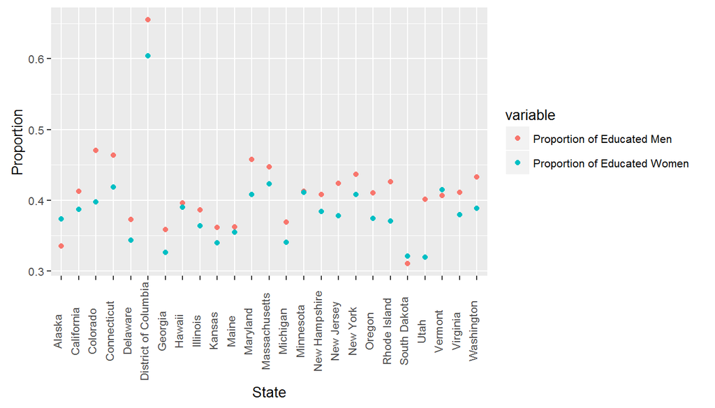

```r
#I just printed the top 10 states to show their proportions.

ggplot(data = sorted_stateproportions[1:25,], aes(x= State, y = Proportion, color = variable)) +
    geom_point(aes(x = X_state,y = prop_educatedmen, col = "Proportion of Educated Men")) +
    geom_point(aes(x= X_state,y = prop_educatedwomen, col = "Proportion of Educated Women"))+
  theme(text = element_text(size=10),axis.text.x = element_text(angle=90, vjust=0))
```

```r
#This displays the plot graph of the proportions of college grad men and women to the total population in that state. I only picked the top 25 states as the graph got too conjusted. Also, I edited the theme to adjust font size as well as to make the axis labels vertical so that it did not overlap and was readable.
```

From the results, we can easily see that the District of Columbia has the highest proportion of both college educated men and women in comparison to its total population as more than 60% of both genders are college grads. Besides that state, no other state has above 50% of either gender being college grads. One other interesting thing to note in the top 25 states, there is a higher proportion of men who are college grads than the proportion of women except for Alaska, South Dakota and Vermont.

**Research question 2:**

```r
smokers <- brfss2013[complete.cases(brfss2013[68]),]
bingedrinkers <- brfss2013[complete.cases(brfss2013[75]),]
#Here we are removing all NA values for "smoked at least 100 cigarettes" and "bingedrinkers"
proportion_smokers <- smokers %>%
  group_by(income2) %>%
  summarize(proportion_smokers = sum(smoke100 =="Yes")/n())

proportion_bingedrinkers <- bingedrinkers %>%
  group_by(income2) %>%
  summarize(proportion_drinkers= sum(drnk3ge5 >0)/n())

#Above we have calculated the proportion of smokers and the proportion of binge drinkers as a function of income level. Then I stored them into proportion_smokers and proportion_bingedrinkers respectively.

smokers_or_drinkers <- data.frame(proportion_smokers,proportion_bingedrinkers[2])
#Here we have combined proportion_smokers and proportion_bingdrinkers into one data frame called smokers_or_drinkers which will make graphing it easier.

smokers_or_drinkers[1:8,]
```

```
##             income2 proportion_smokers proportion_drinkers
## 1 Less than $10,000          0.5267485           0.3842469
## 2 Less than $15,000          0.5515152           0.3299260
## 3 Less than $20,000          0.5186071           0.3124056
## 4 Less than $25,000          0.5091066           0.2773755
## 5 Less than $35,000          0.4918490           0.2621790
## 6 Less than $50,000          0.4743822           0.2576987
## 7 Less than $75,000          0.4402644           0.2461584
## 8   $75,000 or more          0.3720521           0.2411170
```

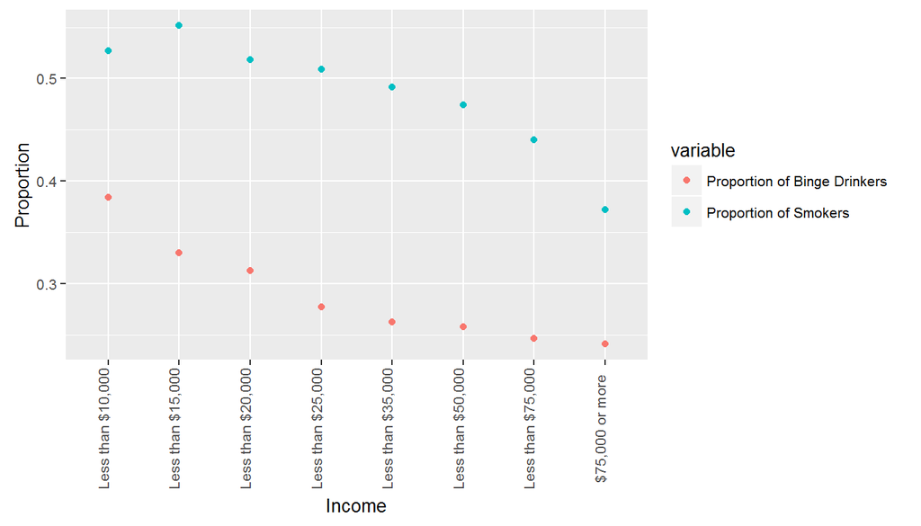

```r
#Here is what the dataframe looks like. We can clearly see that the proportion decreases as income increases.

ggplot(data = smokers_or_drinkers[1:8,], aes(x=Income, y=Proportion,color = variable)) +
  geom_point(aes(x=income2,y=proportion_smokers, col="Proportion of Smokers"))+
  geom_point(aes(x=income2,y=proportion_drinkers, col="Proportion of Binge Drinkers"))+
   theme(text = element_text(size=10),axis.text.x = element_text(angle=90, vjust=0))
```

```r
#This is graphing the income levels of individuals in relation to the proportion of smokers and binge drinkers for that income group. Also, I edited the theme to adjust font size as well as to make the axis labels vertical so that it did not overlap and was readable.
```

**Research question 3:**

```r
veterans <- brfss2013 %>%
  filter(veteran3 == "Yes")
veterans <- veterans[complete.cases(veterans[21]),]

non_vets <- brfss2013 %>%
  filter(veteran3 == "No")
non_vets <- non_vets[complete.cases(non_vets[21]),]
# Here we filter the dataset for only veterans and then for non-veterans. Also, we clean the data to ensure that the mental health values are given and not NA.

vet_life<-veterans %>%
  group_by(rrclass2) %>%
  summarize(vet_mentalhealth_problemslast30 = mean(menthlth), n())

vet_life
```

```
## # A tibble: 8 × 3
##                                  rrclass2 vet_mentalhealth_problemslast30
##                                    <fctr>                           <dbl>
## 1                                   White                        2.706564
## 2               Black or African American                        3.838710
## 3                      Hispanic or Latino                        4.344828
## 4                                   Asian                        6.000000
## 5 Native Hawaiian or Other Pacific Island                        0.000000
## 6        American Indian or Alaska Native                        5.000000
## 7                        Some Other Group                        6.666667
## 8                                      NA                        2.869267
## # ... with 1 more variables: `n()` <int>
```

```r
non_vet_life<-non_vets %>%
  group_by(rrclass2) %>%
  summarize(nonvet_mentalhealth_problemslast30 = mean(menthlth), n())

non_vet_life
```

```
## # A tibble: 8 × 3
##                                  rrclass2
##                                    <fctr>
## 1                                   White
## 2               Black or African American
## 3                      Hispanic or Latino
## 4                                   Asian
## 5 Native Hawaiian or Other Pacific Island
## 6        American Indian or Alaska Native
## 7                        Some Other Group
## 8                                      NA
## # ... with 2 more variables: nonvet_mentalhealth_problemslast30 <dbl>,
## #   `n()` <int>
```

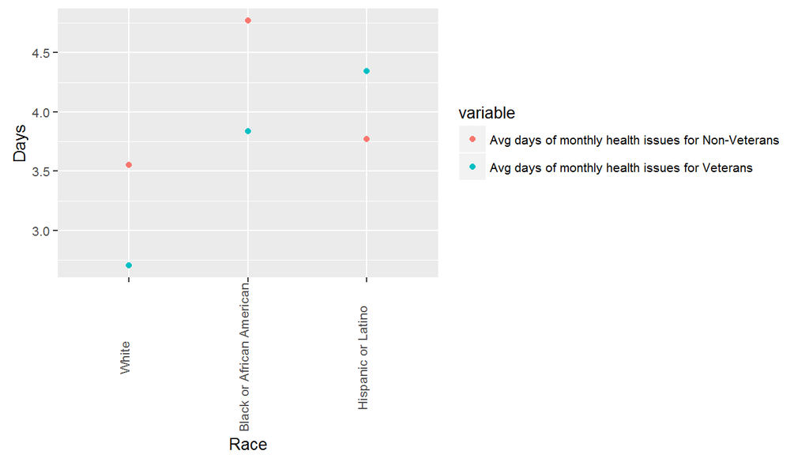

```r
#Here we group the the veteran/non-veteran groups by race. We then find the average number of days per month where mental health has been an issue.

mental_health <- data.frame(vet_life,non_vet_life[2:3])
#Here we combine the the veteran results with the non-veteran results to properly compare the two.

sig_mental_health <- data.frame(mental_health[1:3,],mental_health[8,])
#Since some of the races had less than 30 veterans, they have been omitted as the averages would be unfairly compared as the veteran mental health averages would be too skewed by the low number.

ggplot(data = sig_mental_health, aes(Race, Days, colour= variable)) +
  geom_point(aes(x=rrclass2,y=vet_mentalhealth_problemslast30, col="Avg days of monthly health issues for Veterans"))+
  geom_point(aes(x=rrclass2,y=nonvet_mentalhealth_problemslast30,  col="Avg days of monthly health issues for Non-Veterans"))+
  theme(text = element_text(size=10),axis.text.x = element_text(angle=90, vjust=0))
```

```r
#Here we graph the two blocks and create a point chart which helps compare the mental health problems averages per race depending on veteran or non-veteran status. Also, I edited the theme to adjust font size as well as to make the axis labels vertical so that it did not overlap and was readable.
```